# 13.10 Continuous probability

In Section 8.4, we explained why when summarizing a list of numeric values, such as heights, it is not useful to construct a distribution that defines a proportion to each possible outcome. For example, if we measure every single person in a very large population of size n with extremely high precision, since no two people are exactly the same height, we need to assign the proportion 1/n to each observed value and attain no useful summary at all. Similarly, when defining probability distributions, it is not useful to assign a very small probability to every single height.

Just as when using distributions to summarize numeric data, it is much more practical to define a function that operates on intervals rather than single values. The standard way of doing this is using the cumulative distribution function (CDF).

We described empirical cumulative distribution function (eCDF) in Section 8.4 as a basic summary of a list of numeric values. As an example, we earlier defined the height distribution for adult male students. Here, we define the vector x to contain these heights:

```r
library(tidyverse)
library(dslabs)
data(heights)
x <- heights %>% filter(sex=="Male") %>% pull(height)
```

We defined the empirical distribution function as:

```r
F <- function(a) mean(x<=a)
```

which, for any value a, gives the proportion of values in the list x that are smaller or equal than a.

```r
1 - F(70)
```

```
[1] 0.3768473
```

Once a CDF is defined, we can use this to compute the probability of any subset. For instance, the probability of a student being between height a and height b is:

```r
F(b)-F(a)
```

Because we can compute the probability for any possible event this way, the cumulative probability function defines the probability distribution for picking a height at random from our vector of heights x.

# 13.11 Theoretical continuous distributions

In Section 8.8 we introduced the normal distribution as a useful approximation to many naturally occurring distributions, including that of height. The cumulative distribution for the normal distribution is defined by a mathematical formula which in R can be obtained with the function pnorm. We say that a random quantity is normally distributed with average m and standard deviation s if its probability distribution is defined by:

```r
F(a) = pnorm(a, m, s)
```

```r
m <- mean(x)
s <- sd(x)
1 - pnorm(70.5, m, s)
```

```
[1] 0.371369
```

### 13.11.1 Theoretical distributions as approximations

The normal distribution is derived mathematically: we do not need data to define it. For practicing data scientists, almost everything we do involves data. Data is always, technically speaking, discrete. For example, we could consider our height data categorical with each specific height a unique category. The probability distribution is defined by the proportion of students reporting each height. Here is a plot of that probability distribution:

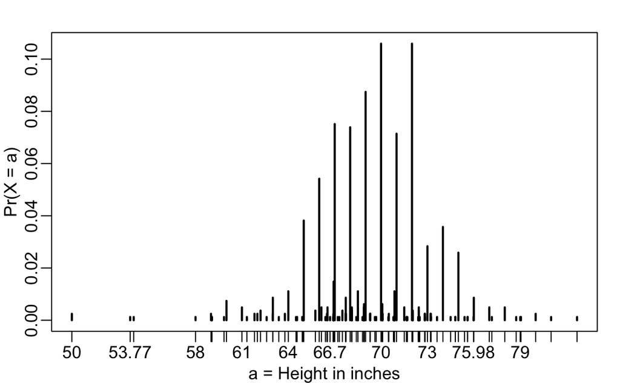

```r
knitr::include_graphics("plot-of-height-frequencies-1.png")
```

While most students rounded up their heights to the nearest inch, others reported values with more precision. One student reported his height to be 69.6850393700787, which is 177 centimeters. The probability assigned to this height is 0.001 or 1 in 812. The probability for 70 inches is much higher at 0.106, but does it really make sense to think of the probability of being exactly 70 inches as being different than 69.6850393700787? Clearly it is much more useful for data analytic purposes to treat this outcome as a continuous numeric variable, keeping in mind that very few people, or perhaps none, are exactly 70 inches, and that the reason we get more values at 70 is because people round to the nearest inch.

With continuous distributions, the probability of a singular value is not even defined. For example, it does not make sense to ask what is the probability that a normally distributed value is 70. Instead, we define probabilities for intervals. We thus could ask what is the probability that someone is between 69.5 and 70.5.

In cases like height, in which the data is rounded, the normal approximation is particularly useful if we deal with intervals that include exactly one round number. For example, the normal distribution is useful for approximating the proportion of students reporting values in intervals like the following three:

```r
mean(x <= 68.5) - mean(x <= 67.5)
```

```
[1] 0.114532
```

```r
mean(x <= 69.5) - mean(x <= 68.5)
```

```
[1] 0.1194581
```

```r
mean(x <= 70.5) - mean(x <= 69.5)
```

```
[1] 0.1219212
```

Note how close we get with the normal approximation:

```r
pnorm(68.5, m, s) - pnorm(67.5, m, s)
```

```
[1] 0.1031077
```

```r
pnorm(69.5, m, s) - pnorm(68.5, m, s)
```

```
[1] 0.1097121
```

```r
pnorm(70.5, m, s) - pnorm(69.5, m, s)
```

```
[1] 0.1081743
```

However, the approximation is not as useful for other intervals. For instance, notice how the approximation breaks down when we try to estimate:

```r
mean(x <= 70.9) - mean(x<=70.1)
```

```
[1] 0.02216749
```

with

```r
pnorm(70.9, m, s) - pnorm(70.1, m, s)
```

```
[1] 0.08359562
```

In general, we call this situation discretization. Although the true height distribution is continuous, the reported heights tend to be more common at discrete values, in this case, due to rounding. As long as we are aware of how to deal with this reality, the normal approximation can still be a very useful tool.

### 13.11.2 The probability density

For categorical distributions, we can define the probability of a category. For example, a roll of a die, let’s call it X, can be 1,2,3,4,5 or 6. The probability of 4 is defined as: Pr(X=4)=1/6 The CDF can then easily be defined: F(4)=Pr(X≤4)=Pr(X=4)+Pr(X=3)+Pr(X=2)+Pr(X=1) Although for continuous distributions the probability of a single value  
Pr(X=x) is not defined, there is a theoretical definition that has a similar interpretation. The probability density at x is defined as the function f(a) such that:

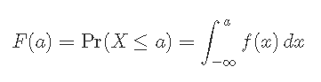

```r
knitr::include_graphics("continuous-probability.png")
```

For those that know calculus, remember that the integral is related to a sum: it is the sum of bars with widths approximating 0. If you don’t know calculus, you can think of f(x) as a curve for which the area under that curve up to the value a, gives you the probability Pr(X≤a).

For example, to use the normal approximation to estimate the probability of someone being taller than 76 inches, we use:

```r
1 - pnorm(76, m, s)
```

```
[1] 0.03206008
```

which mathematically is the grey area below:

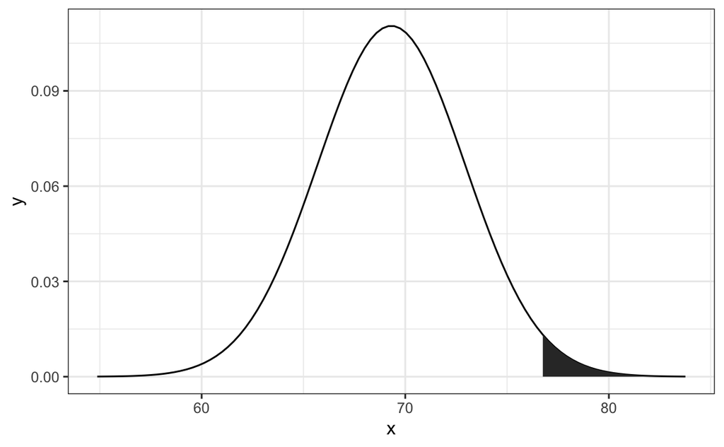

```r
knitr::include_graphics("intergrals-1.png")
```

The curve you see is the probability density for the normal distribution. In R, we get this using the function dnorm.

Although it may not be immediately obvious why knowing about probability densities is useful, understanding this concept will be essential to those wanting to fit models to data for which predefined functions are not available.

# 13.12 Monte Carlo simulations for continuous variables

R provides functions to generate normally distributed outcomes. Specifically, the rnorm function takes three arguments: size, average (defaults to 0), and standard deviation (defaults to 1) and produces random numbers. Here is an example of how we could generate data that looks like our reported heights:

```r
n <- length(x)
m <- mean(x)
s <- sd(x)
simulated_heights <- rnorm(n, m, s)
```

Not surprisingly, the distribution looks normal:

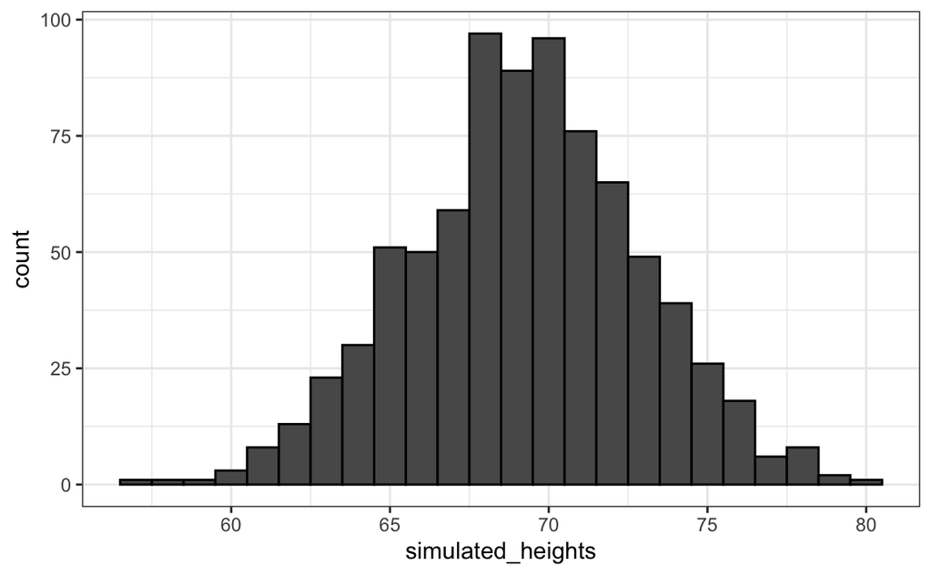

```r
knitr::include_graphics("simulated-heights-1.png")
```

This is one of the most useful functions in R as it will permit us to generate data that mimics natural events and answers questions related to what could happen by chance by running Monte Carlo simulations.

If, for example, we pick 800 males at random, what is the distribution of the tallest person? How rare is a seven footer in a group of 800 males? The following Monte Carlo simulation helps us answer that question:

```r
B <- 10000
tallest <- replicate(B, {
  simulated_data <- rnorm(800, m, s)
  max(simulated_data)
})
```

Having a seven footer is quite rare:

```r
mean(tallest >= 7*12)
```

```
[1] 0.0189
```

Here is the resulting distribution:

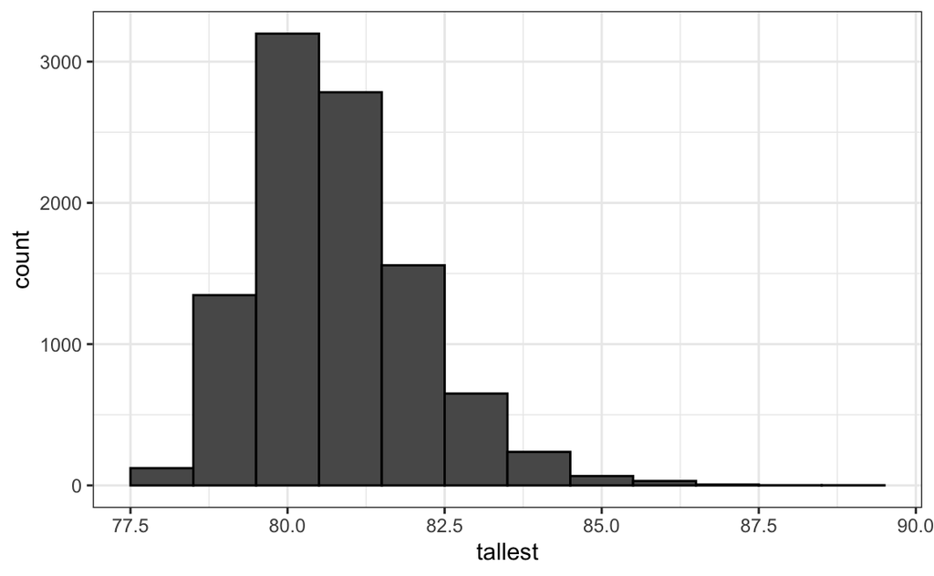

```r
knitr::include_graphics("simulated-tallest-height-1.png")
```

Note that it does not look normal.